# SARIMA

Flávio Macaúbas Torres Filho e José Carlos Claudino Filho

27/04/2022

# Modelo SARIMA(p,d,q)(P, D, Q)S

## Principais conclusões:

- A série utilizada é o **Preço Mensal do Barril do Petróleo Bruto - Brent da Europa (U$)**
  - Por tratar-se de dados mensais, **S = 12**
- **Não foi necessário** realizar a diferença sazonal da série
- A série não é estacionária, tivemos que aplicar a **primeira diferença para estabilizá-la**
- O melhor modelo a partir dos critério de informação AIC foi **SARIMA(2,1,1)(2,0,0)12**
- O melhor modelo a partir dos critério de informação BIC foi **SARIMA(1,1,0)(2,0,0)12**
- As raízes estão **dentro do círculo unitário** para ambos os modelos

> Modelo critério AIC - SARIMA(2,1,1)(2,0,0)12
- **A previsão para abril de 2022 do Preço do Barril do Petróleo Bruto - Brent para Europa é de U$ 125,02** - com intervalo entre U$ 116,29 e U$ 133,75.

Sazonalidade em séries temporais são padrões regulares que se repetem ao longo do tempo, onde **S** define o número de períodos até que o padrão volte a se repetir. A presença de sazonalidade pode fazer com que a série não seja estacionária, sendo necessário modelar esse componente para que sejamos capazes de trabalhar com a série.

O modelo Seasonal ARIMA (SARIMA) permite tal abordagem, pois incorpora tanto os fatores não-sazonal, quanto os fatores sazonal em um modelo multiplicativo. Podendo ser formalizado pela seguinte notação:

$$ARIMA(p,d,q)\times(P,D,Q)S$$

onde p, d, q são as ordens e diferença do modelo não sazonal e P, D, Q seu pares para o modelo sazonal, destaca-se que S é o intervalo de tempo que o padrão sazonal se repete. Sem diferenciação o modelo pode ser representado da seguite forma:

$$\phi(B^{S})\phi(B)(x_{t} - \mu) =
\theta(B^{S})\theta(B)\omega_{t}$$

Ao qual o componente não sazonal é representado por:

$$AR: \phi(B) = 1 - \phi_{1}B \; - \; ... \; -\; \phi_{p}B^{p}
\\
MA: \theta(B) = 1 - \theta_{1}B \; - \; ... \; -\; \theta_{q}B^{q}$$

Por sua vez, o componente sazonal é representado por:

$$Seasonal \; AR: \phi(B) = 1 - \phi_{1}B^{S} \; - \; ... \; -\;
\phi_{P}B^{PS}
\\
Seasonal \; MA: \theta(B) = 1 - \theta_{1}B^{S} \; - \; ... \; -\;
\theta_{Q}B^{QS}$$

Desta forma, iremos seguir a metodologia Box-Jenkins adaptada a modelagem da sazonalidade:

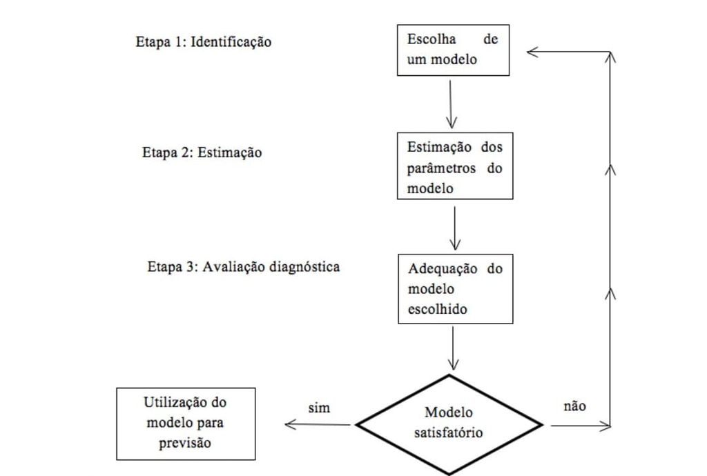

Metodologia Box Jenkins

Para isto, utilizaremos as informações **Preço de Petróleo Bruto - Brent Europa (Preço em dólar do Barril)**, de maio de 1987 até março de 2022, com frequência mensal.

## Instalação e Imports

```r
#install.packages("tidyverse")
#install.packages("skimr")
#install.packages("janitor")
#install.packages('seasonal')
#install.packages('gridExtra')
#install.packages('imputeTS')
#install.packages('tsoutliers')
#install.packages('forecast')
#install.packages('MASS')
#install.packages('tseries')
#install.packages("urca")
```

```r
# Pacote para análise de dado
library(tidyverse)

# Pacotes para limpeza e sumarização de dados
library(skimr)
library(janitor)
library(imputeTS)
library(tsoutliers)

# Dataviz
library(ggplot2)
library(scales)
library(gridExtra)


# Série Temporal
library(seasonal)
library(stats)
library(forecast)
library(MASS) # BoxCox

# Testes de estacionariedade
library(tseries) # ADF, PP e KPSS
library(urca) # ERS


# Configuração número científico
options(scipen = 999)
```

## Carregamento dos dados

```r
# Data loading
petrol = read.csv("C:/Users/Macaubas/Desktop/Mestrado/Cadeiras/Series/Projeto/Series Temporal/Dados/MCOILBRENTEU.csv") %>%
  as_tibble()

# Ajuste do nome das colunas para minúsculo
petrol = petrol %>%
  rename_with(tolower)


# Visualizando os dados
petrol
```

```
## # A tibble: 419 x 2
##    date       mcoilbrenteu
##    <chr>             <dbl>
##  1 1987-05-01         18.6
##  2 1987-06-01         18.9
##  3 1987-07-01         19.9
##  4 1987-08-01         19.0
##  5 1987-09-01         18.3
##  6 1987-10-01         18.8
##  7 1987-11-01         17.8
##  8 1987-12-01         17.0
##  9 1988-01-01         16.8
## 10 1988-02-01         15.7
## # ... with 409 more rows
```

## Sumarização dos dados

```r
skim(petrol)
```

Data summary

| Name | petrol |
| --- | --- |
| Number of rows | 419 |
| Number of columns | 2 |
| _______________________ |  |
| Column type frequency: |  |
| character | 1 |
| numeric | 1 |
| ________________________ |  |
| Group variables | None |

**Variable type: character**

| skim_variable | n_missing | complete_rate | min | max | empty | n_unique | whitespace |
| --- | --- | --- | --- | --- | --- | --- | --- |
| date | 0 | 1 | 10 | 10 | 0 | 419 | 0 |

**Variable type: numeric**

| skim_variable | n_missing | complete_rate | mean | sd | p0 | p25 | p50 | p75 | p100 | hist |
| --- | --- | --- | --- | --- | --- | --- | --- | --- | --- | --- |
| mcoilbrenteu | 0 | 1 | 47.47 | 32.31 | 9.82 | 18.91 | 36.02 | 68.59 | 132.72 | ▇▃▃▁▂ |

## Transformando em série

```r
serie_petrol = ts(start = c(1987,05,01),
                    petrol$mcoilbrenteu,
                    freq = 12)

head(serie_petrol, 20)
```

```
##        Jan   Feb   Mar   Apr   May   Jun   Jul   Aug   Sep   Oct   Nov   Dec
## 1987                         18.58 18.86 19.86 18.98 18.31 18.76 17.78 17.05
## 1988 16.75 15.73 14.73 16.60 16.31 15.54 14.91 14.89 13.18 12.41 13.02 15.31
```

## Graficamente

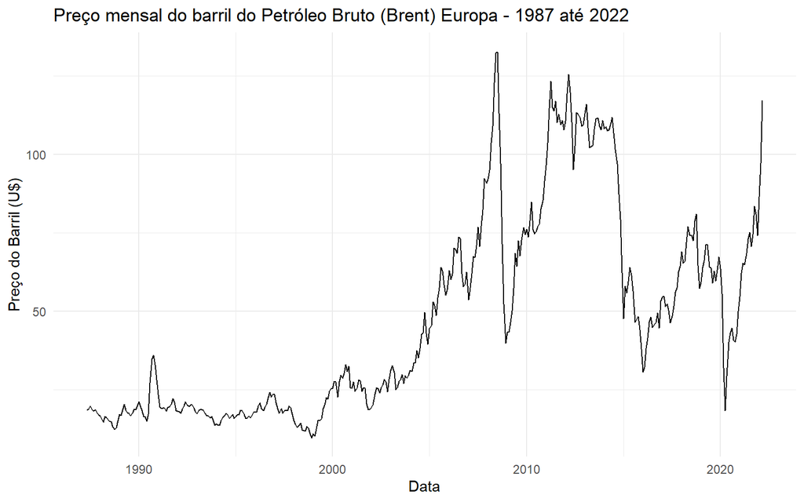

```r
autoplot(serie_petrol) +
  labs( y = 'Preço do Barril (U$)',
        x = 'Data',
        title = 'Preço mensal do barril do Petróleo Bruto (Brent) Europa - 1987 até 2022') +
  theme_minimal()
```

É perceptível que há uma quebra estrutural nos preços em meados da década de 2000, porém, neste momento, não estamos interessados identificar quebras estruturais. Dada esta simplificação, é possível perceber uma clara tendência na série e a presença de componente sazonais. A partir disso, iremos adotar as seguintes etapas:

- Realizar os testes formais estacionariedade
- Retirada da diferença sazonal da série
  - Para isto adotaremos lag = 12, dado que trata-se de uma série mensal
- Retirada da primeira diferença da série

## Testes de estacionariedade

### ADF, PP e KPSS

```r
petrol %>%
  summarize(ADF = adf.test(mcoilbrenteu)$p.value,
            PP = pp.test(mcoilbrenteu)$p.value,
            KPSS = kpss.test(mcoilbrenteu)$p.value) %>%
  gather("Testes", "p-valor")
```

```
## # A tibble: 3 x 2
##   Testes `p-valor`
##   <chr>      <dbl>
## 1 ADF        0.337
## 2 PP         0.269
## 3 KPSS       0.01
```

Podemos verificar que pelo testes de ADF e PP **não é possível rejeitar a hipótese nula**, indicando que a série possui raízes unitárias. Pelo teste de KPSS - onde a hipótese nula indica ausência de raíz unitária - **é possível rejeitar a hipótese nula**, sugerindo a presença de raíz unitária. Desta forma, os três testes iniciais indicam que a **série não é estacionária**.

Para complementar a análise de estacionaridade, realizaremoso teste ERS:

### Elliot, Rothenberg e Stock - ERS

```r
summary(ur.ers(serie_petrol))
```

```
##
## ###############################################
## # Elliot, Rothenberg and Stock Unit Root Test #
## ###############################################
##
## Test of type DF-GLS
## detrending of series with intercept
##
##
## Call:
## lm(formula = dfgls.form, data = data.dfgls)
##
## Residuals:
##      Min       1Q   Median       3Q      Max
## -20.0562  -1.5639   0.2981   2.5754  16.0293
##
## Coefficients:
##               Estimate Std. Error t value            Pr(>|t|)
## yd.lag       -0.003559   0.005642  -0.631               0.528
## yd.diff.lag1  0.409358   0.050260   8.145 0.00000000000000465 ***
## yd.diff.lag2 -0.038852   0.054139  -0.718               0.473
## yd.diff.lag3 -0.060046   0.054566  -1.100               0.272
## yd.diff.lag4 -0.029424   0.051288  -0.574               0.566
## ---
## Signif. codes:  0 '***' 0.001 '**' 0.01 '*' 0.05 '.' 0.1 ' ' 1
##
## Residual standard error: 4.558 on 409 degrees of freedom
## Multiple R-squared:  0.1561, Adjusted R-squared:  0.1457
## F-statistic: 15.13 on 5 and 409 DF,  p-value: 0.0000000000001214
##
##
## Value of test-statistic is: -0.6308
##
## Critical values of DF-GLS are:
##                  1pct  5pct 10pct
## critical values -2.57 -1.94 -1.62
```

A hipótese nula do teste sugere presença de raíz unitária, como o valor calculado -0.6308 está dentro de todos os níveis de significância, **não podemos rejeitar a hipótese nula** de presença de raíz unitária na série. Logo, o teste ERS, indica a **não estacionariedade** da série.

Iremos aplicar a diferença sazonal da série e, se necessário, a diferença da série em busca da estacionariedade.

## Checando quantidade de diferenças necessárias

### Não-Sazonal

```r
ndiffs(serie_petrol)
```

```
## [1] 1
```

### Sazonal

```r
nsdiffs(serie_petrol)
```

```
## [1] 0
```

Os resultados acima sugerem que é necessário aplicar a primeira diferença para o componente não-sazonal do nosso modelo e não há necessidade de aplicar nenhuma diferença para o componente sazonal. Assim, temos que **d = 1** e **D = 0**. Como trata-se de uma série mensal, adotaremos **S = 12**.

## Aplicando primeira diferença

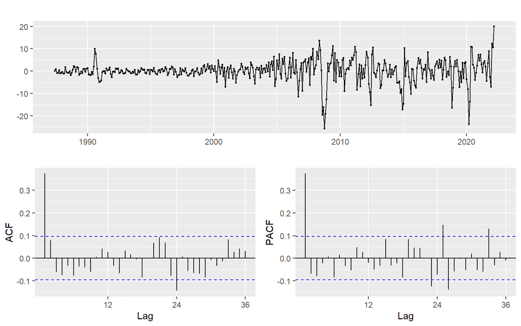

```r
serie_petrol %>%
  diff() %>%
  ggtsdisplay()
```

Analisando a Função de Autocorrelação (ACF) é possível perceber que há um *spike* no lag 1, sugerindo um processo de AR(1) para a série não-sazonal. Por sua vez, como há um *spike* significativo no lag 24 (múltiplo de S), sugere-se um AR(2) para o modelo sazonal.

É necessário checar todas as possíveis combinações de modelo e, através dos critérios de informação (AIC e BIC), selecionar o melhor modelo possível - pelo princípio da parcimônia.

Por questão de viabilidade, dado a quantidade de combinação de modelos necessários, iremos adotar a função auto.arima para nos retornar o melhor modelo para nossa série.

## SARIMA - critério AIC

```r
auto.arima(serie_petrol,
           ic = 'aic',
           stepwise = FALSE,
           approximation = FALSE)
```

```
## Series: serie_petrol
## ARIMA(2,1,1)(2,0,0)[12]
##
## Coefficients:
##          ar1      ar2      ma1    sar1     sar2
##       1.2420  -0.3948  -0.8326  0.0397  -0.1917
## s.e.  0.1501   0.0570   0.1564  0.0527   0.0501
##
## sigma^2 estimated as 19.83:  log likelihood=-1215.45
## AIC=2442.89   AICc=2443.1   BIC=2467.1
```

Pelo critério AIC, temos que o melhor modelo é:

$$SARIMA(2,1,1)(2,0,0)(S = 12)$$

## SARIMA - critério BIC

```r
auto.arima(serie_petrol,
           ic = 'bic',
           stepwise = FALSE,
           approximation = FALSE)
```

```
## Series: serie_petrol
## ARIMA(1,1,0)(2,0,0)[12]
##
## Coefficients:
##          ar1    sar1     sar2
##       0.3959  0.0392  -0.1821
## s.e.  0.0455  0.0498   0.0501
##
## sigma^2 estimated as 20.03:  log likelihood=-1218.56
## AIC=2445.11   AICc=2445.21   BIC=2461.25
```

Pelo critério BIC, temos que o melhor modelo é:

$$SARIMA(1,1,0)(2,0,0)(S = 12)$$

## Estimando os modelos

```r
# Critério AIC
modelo_aic = Arima(serie_petrol,
                   order=c(2,1,1),
                   seasonal = c(2,0,0))

# Critério BIC
modelo_bic = Arima(serie_petrol,
                   order=c(1,1,0),
                   seasonal = c(2,0,0))
```

## Checando Resíduos

### Modelo critério AIC

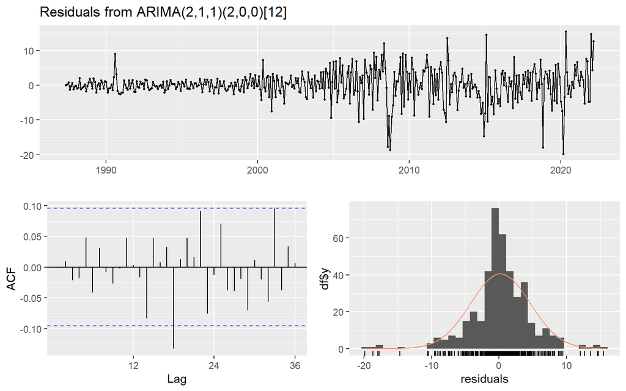

```
##
##  Ljung-Box test
##
## data:  Residuals from ARIMA(2,1,1)(2,0,0)[12]
## Q* = 23.759, df = 19, p-value = 0.2056
##
## Model df: 5.   Total lags used: 24
```

```r
checkresiduals(modelo_aic)
```

Como o teste de Ljung-Box **falha em rejeitar a hipótese nula**, aceitamos o erro como ruído branco.

### Modelo critério BIC

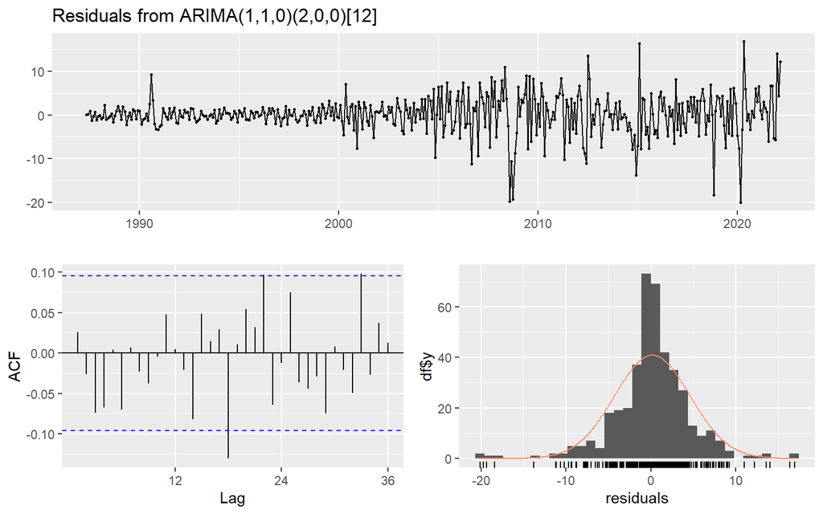

```
##
##  Ljung-Box test
##
## data:  Residuals from ARIMA(1,1,0)(2,0,0)[12]
## Q* = 28.807, df = 21, p-value = 0.1187
##
## Model df: 3.   Total lags used: 24
```

```r
checkresiduals(modelo_bic)
```

Similarmente, o teste de Ljung-Box **falha em rejeitar a hipótese nula**, aceitamos o erro como ruído branco.

## Presença de Raíz Unitária

### Modelo critério AIC

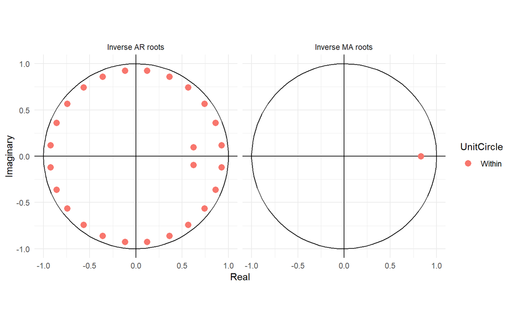

```r
autoplot(modelo_aic) + theme_minimal()
```

Podemos verificar para o modelo SARIMA(2,1,1)(2,0,0)12, os valores de $\phi$ e $\theta$ estão **dentro do círculo unitário**.

### Modelo critério BIC

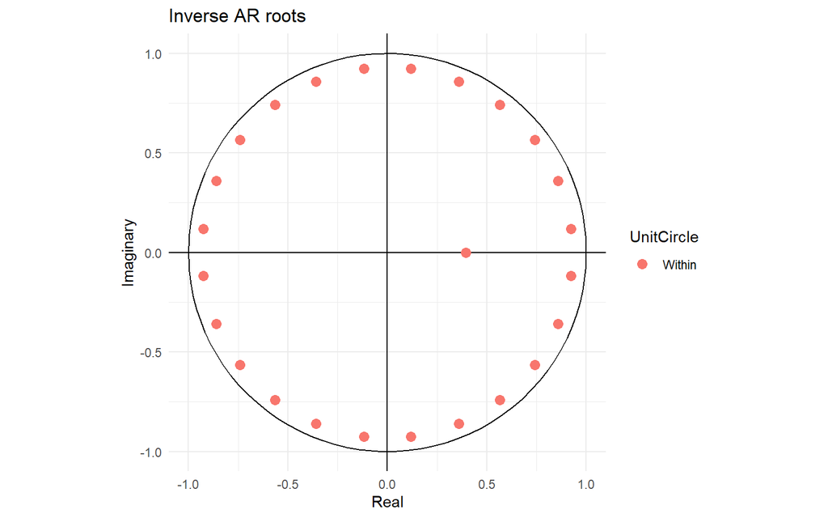

```r
autoplot(modelo_bic) + theme_minimal()
```

Podemos verificar para o modelo SARIMA(1,1,0)(2,0,0)12, os valores de $\phi$ estão **dentro do círculo unitário**. Neste caso, não há componente MA em nenhum dos modelos - sazonal ou não-sazonal.

## Modelo critério AIC

```r
forecast(modelo_aic)
```

```
##          Point Forecast     Lo 80    Hi 80     Lo 95    Hi 95
## Apr 2022      125.02634 119.32019 130.7325 116.29953 133.7532
## May 2022      123.40341 113.54250 133.2643 108.32245 138.4844
## Jun 2022      119.87125 106.72724 133.0153  99.76922 139.9733
## Jul 2022      117.22574 101.53265 132.9188  93.22524 141.2262
## Aug 2022      114.72817  97.03465 132.4217  87.66827 141.7881
## Sep 2022      113.93480  94.63036 133.2392  84.41121 143.4584
## Oct 2022      113.15379  92.50920 133.7984  81.58062 144.7270
## Nov 2022      111.65019  89.85283 133.4476  78.31400 144.9864
## Dec 2022      109.33300  86.51333 132.1527  74.43333 144.2327
## Jan 2023      108.47068  84.72084 132.2205  72.14844 144.7929
## Feb 2023      107.16609  82.55258 131.7796  69.52298 144.8092
## Mar 2023      107.18061  81.75276 132.6085  68.29207 146.0692
## Apr 2023      107.48903  81.22905 133.7490  67.32786 147.6502
## May 2023      106.64123  79.56014 133.7223  65.22428 148.0582
## Jun 2023      105.57165  77.69238 133.4509  62.93399 148.2093
## Jul 2023      105.05708  76.40579 133.7084  61.23871 148.8754
## Aug 2023      105.79153  76.39369 135.1894  60.83142 150.7516
## Sep 2023      105.03582  74.91477 135.1569  58.96965 151.1020
## Oct 2023      103.26642  72.44302 134.0898  56.12609 150.4068
## Nov 2023      103.68230  72.17509 135.1895  55.49619 151.8684
## Dec 2023      104.90841  72.73400 137.0828  55.70189 154.1149
## Jan 2024      102.50875  69.68211 135.3354  52.30473 152.7128
## Feb 2024      100.42147  66.95623 133.8867  49.24080 151.6021
## Mar 2024       96.56568  62.47440 130.6570  44.42757 148.7038
```

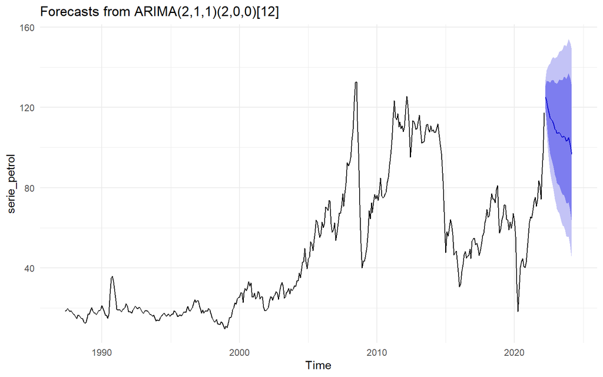

```r
autoplot(forecast(modelo_aic)) + theme_minimal()
```

O modelo SARIMA(2,1,1)(2,0,0)12 a previsão para Abril de 2022 o preço do Barril de Petróleo Bruto - BRENT Europa será de **U$ 125,02**. Seguidos por uma queda considerável do preço no meses a seguir.

## Modelo critério BIC

```r
forecast(modelo_bic)
```

```
##          Point Forecast     Lo 80    Hi 80     Lo 95    Hi 95
## Apr 2022       125.9204 120.18442 131.6563 117.14799 134.6927
## May 2022       126.5215 116.67223 136.3708 111.45833 141.5847
## Jun 2022       125.6929 112.41438 138.9715 105.38514 146.0007
## Jul 2022       125.6161 109.42674 141.8055 100.85659 150.3756
## Aug 2022       125.3222 106.60048 144.0439  96.68981 153.9546
## Sep 2022       126.2268 105.25159 147.2021  94.14798 158.3057
## Oct 2022       126.7367 103.71849 149.7548  91.53340 161.9399
## Nov 2022       126.1932 101.29579 151.0905  88.11593 164.2704
## Dec 2022       124.5975  97.95195 151.2431  83.84664 165.3484
## Jan 2023       124.2121  95.92572 152.4985  80.95181 167.4724
## Feb 2023       123.2611  93.42383 153.0984  77.62893 168.8933
## Mar 2023       123.4800  92.16849 154.7916  75.59316 171.3669
## Apr 2023       123.9293  91.14391 156.7147  73.78836 174.0703
## May 2023       123.2753  89.05411 157.4966  70.93848 175.6122
## Jun 2023       122.3995  86.79061 158.0084  67.94039 176.8587
## Jul 2023       122.0304  85.08217 158.9786  65.52296 178.5378
## Aug 2023       122.8240  84.58187 161.0661  64.33772 181.3102
## Sep 2023       122.1782  82.68406 161.6724  61.77712 182.5793
## Oct 2023       120.5498  79.84186 161.2577  58.29239 182.8072
## Nov 2023       120.9820  79.09541 162.8686  56.92198 185.0420
## Dec 2023       122.1726  79.13957 165.2057  56.35925 187.9860
## Jan 2024       119.9098  75.76008 164.0596  52.38861 187.4311
## Feb 2024       117.9382  72.69926 163.1771  48.75123 187.1251
## Mar 2024       114.2820  67.97953 160.5844  43.46850 185.0954
```

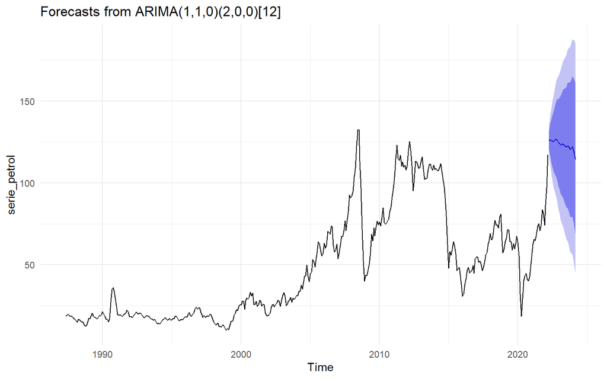

```r
autoplot(forecast(modelo_bic)) + theme_minimal()
```

Por sua vez, o modelo SARIMA(1,1,0)(2,0,0)12 a previsão para Abril de 2022 o preço do Barril de Petróleo Bruto - BRENT Europa será de **U$ 125,92**. Todavia, o modelo capta uma queda mais suave do preço do barril de petróleo.

## Referências

HYNDMAN, Rob J.; ATHANASOPOULOS, George. **Forecasting: principles and practice**. OTexts, 2018.

[PennState](https://online.stat.psu.edu/stat510/lesson/4/4.1) [RPubs](https://rpubs.com/ryankelly/tsa5)